# USDR Appointment Availability Data - Coverage

Last compiled at 2021-06-15 17:53

## Sample Data

Here are the actual availability counts (not necessarily slot-level data) for a sample of 25 locations. You can see different supply patterns, and some example locations that only publish “has availability” (rather than “x appointments”) info.

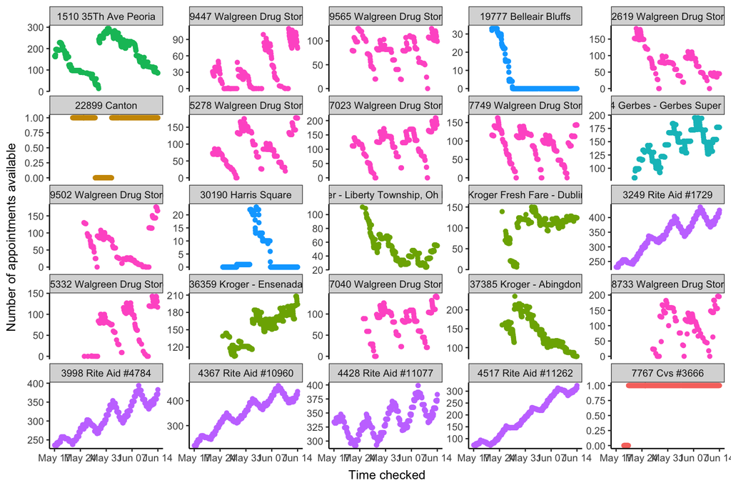

## Slot-level data over time

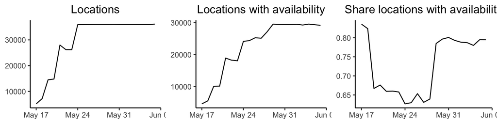

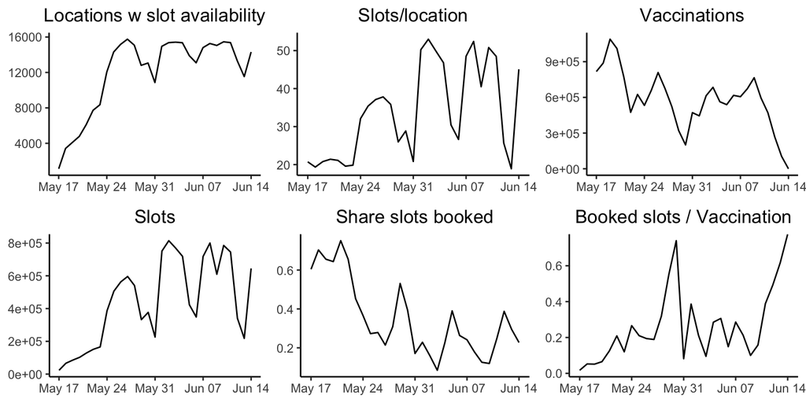

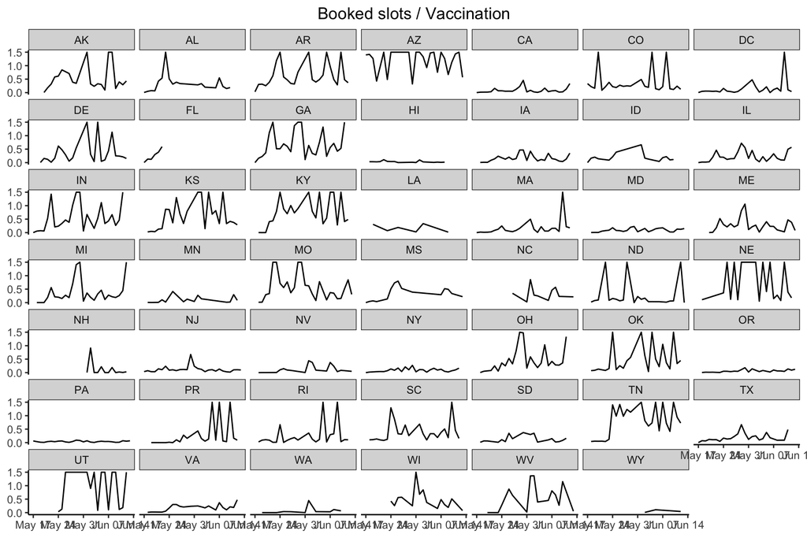

## Coverage by state

We look at how many locations we have, how many have availability at all, how many report slot-level data. Then we compare these to the population and the number of vaccinations that happened during this time (two weeks). These numbers might not match up (slots could stop being available without being booked, not all bookings will be of a 2nd shot, vaccinations could be reported later), so the “share of vaccinations covered” statistic could go over 100%.

|  | State | Pop (M) | Vax. last 2 weeks | Locations | Locations with av. | Share locations with av. | Locations with slot | Share locations with slots | Slots | Slots per location | Slots per person | Slots booked | Share slots booked | Share vax in data | Locations (VtS) | Share VtS locations |
| --- | --- | --- | --- | --- | --- | --- | --- | --- | --- | --- | --- | --- | --- | --- | --- | --- |
| 1 | AK | 0.7 | 14486 | 64 | 33 | 0.516 | 30 | 0.909 | 29456 | 982 | 0.04 | 7064 | 0.24 | 0.488 | 204 | 0.309 |
| 2 | AL | 4.9 | 72362 | 931 | 575 | 0.618 | 351 | 0.61 | 203041 | 578 | 0.042 | 37959 | 0.187 | 0.525 | 1586 | 0.533 |
| 3 | AR | 3.0 | 56725 | 350 | 246 | 0.703 | 219 | 0.89 | 156277 | 714 | 0.052 | 36996 | 0.237 | 0.652 | 706 | 0.483 |
| 4 | AZ | 7.1 | 70035 | 873 | 806 | 0.923 | 491 | 0.609 | 420680 | 857 | 0.06 | 97209 | 0.231 | 1.388 | 1450 | 0.506 |
| 5 | CA | 39.3 | 1613357 | 3686 | 2724 | 0.739 | 935 | 0.343 | 625993 | 670 | 0.016 | 102736 | 0.164 | 0.064 | 6315 | 0.396 |
| 6 | CO | 5.6 | 255852 | 788 | 591 | 0.75 | 437 | 0.739 | 317505 | 727 | 0.057 | 66056 | 0.208 | 0.258 | 1040 | 0.701 |
| 7 | CT | 3.6 | 0 | 422 | 373 | 0.884 | 144 | 0.386 | 115873 | 805 | 0.032 | 23020 | 0.199 |  | 745 | 0.416 |
| 8 | DC | 0.7 | 29176 | 101 | 75 | 0.743 | 15 | 0.2 | 11421 | 761 | 0.016 | 2422 | 0.212 | 0.083 | 135 | 0 |
| 9 | DE | 1.0 | 43395 | 154 | 130 | 0.844 | 71 | 0.546 | 59786 | 842 | 0.062 | 12100 | 0.202 | 0.279 | 220 | 0.627 |
| 10 | FL | 20.9 | 0 | 3350 | 2594 | 0.774 | 1683 | 0.649 | 912629 | 542 | 0.044 | 176818 | 0.194 |  | 4512 | 0.521 |

[output cut: 42 more lines]

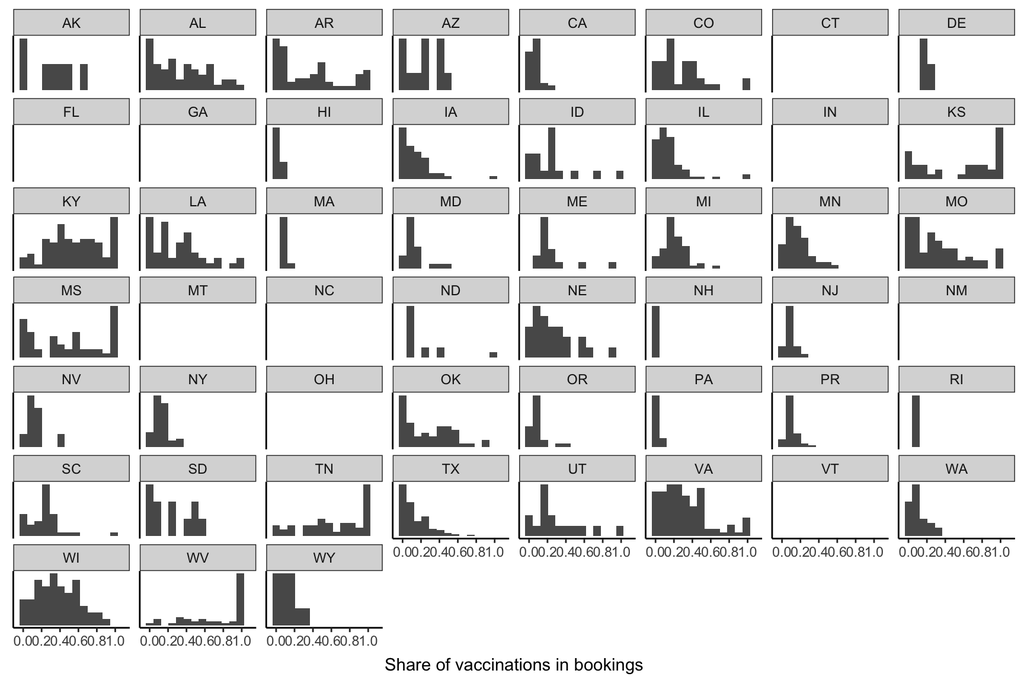

## Coverage of locations compared to vaccinatethestates.org

Here is the total number of locations by county, in our database, as compared to vaccinatethestates.org. This does not take into account whether the location has availability or slot data.

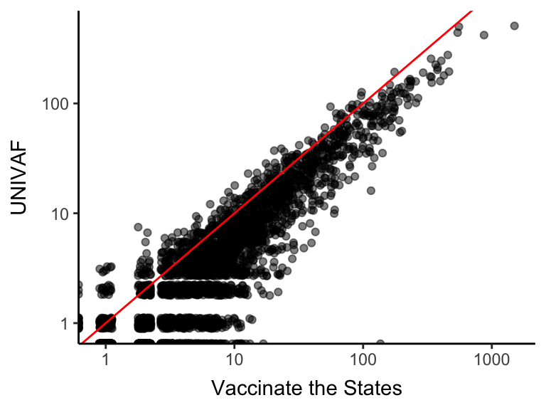

As you can see, VtS often has somewhat more locations than we do.

Here is the distribution of the ratio of the counts:

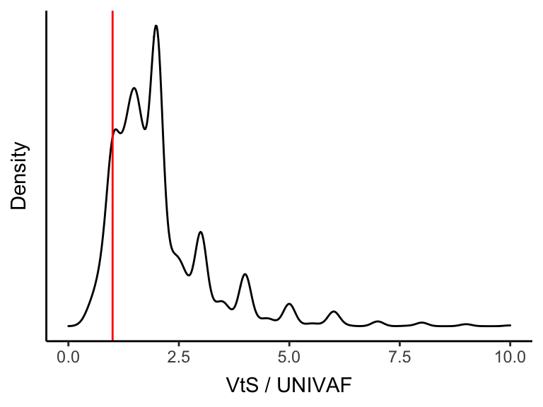

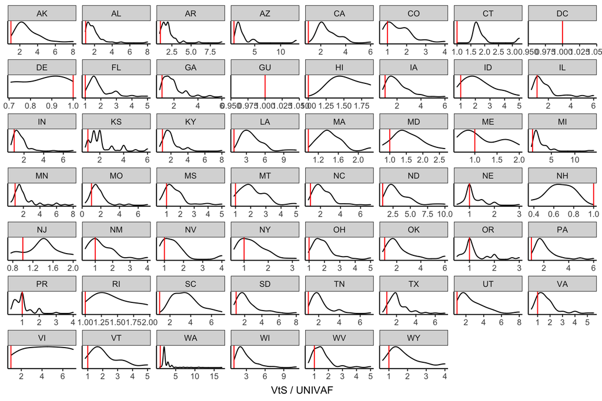

VtS has more locations almost everywhere, except for DE and NH

## Continuity of data

Here we look at how stable data updates are. We count the minutes between updates for each location (taking into account that I’m scraping our API every hour), and take the count, number of updates missed (delta > 90 minutes), average minutes, median, 95 percentile, and 99 percentiles. Then we average those by state and provider.

By state:

|  | state | n_updates | miss | avg | p50 | p95 | p99 | max |
| --- | --- | --- | --- | --- | --- | --- | --- | --- |
| 1 | AK | 462.3125 | 0.056091999333919 | 38.6813026945292 | 29.0065104166667 | 76.1366666666666 | 121.174302083333 | 436.048958333333 |
| 2 | AL | 413.88683351469 | 0.0499706530126664 | 57.0152074724939 | 51.4592401160682 | 90.6470248458469 | 128.381031193326 | 496.699854914762 |
| 3 | AR | 399.513196480938 | 0.0749404306086022 | 58.7363453071492 | 46.0057673509286 | 112.874171554252 | 169.404556207234 | 515.908699902248 |
| 4 | AZ | 516.527293844367 | 0.0881908161239539 | 44.0076718874196 | 26.7467615176152 | 109.817579284424 | 178.230380797522 | 491.18948348174 |
| 5 | CA | 449.798687089716 | 0.0525366709204094 | 44.6081794672106 | 35.9109949398249 | 81.1323704108922 | 123.538815771638 | 315.655508904692 |
| 6 | CO | 533.343195266272 | 0.0807478814376212 | 41.3554030425952 | 24.8040873602893 | 100.477955292571 | 171.671367977482 | 548.292384122288 |
| 7 | CT | 431.361045130641 | 0.0790036929875833 | 55.7946142251854 | 44.9922307996833 | 108.61824854843 | 174.349038598575 | 389.189083531275 |
| 8 | DC | 452.009900990099 | 0.0431358695055418 | 53.4437678595406 | 46.7149339933993 | 84.8923514851485 | 130.517788778878 | 360.73201320132 |
| 9 | DE | 443.320261437908 | 0.103983706516086 | 43.8580276495481 | 28.4180337690632 | 113.044335330428 | 203.556204393609 | 410.734958242556 |
| 10 | FL | 419.891376701967 | 0.0751338417402828 | 56.2055658084145 | 43.72976802824 | 108.775014372163 | 173.502397226424 | 381.529747856783 |

[output cut: 43 more lines]

By provider (with at least 100 locations):

|  | provider | n_updates | miss | avg | p50 | p95 | p99 | max |
| --- | --- | --- | --- | --- | --- | --- | --- | --- |
| 1 | albertsons | 560.628318584071 | 0.000218666392261782 | 1.20351245398001 | 0 | 7.28271386430678 | 7.35564257620452 | 20.4533923303835 |
| 2 | albertsons_jewelosco | 582.972222222222 | 0 | 0 | 0 | 0 | 0 | 0 |
| 3 | albertsons_safeway | 575.737346101231 | 0.000375679800508984 | 2.57201035689465 | 0 | 15.5847013223894 | 15.7265836753306 | 38.8182626538988 |
| 4 | albertsons_vons | 577.991304347826 | 0 | 0 | 0 | 0 | 0 | 0 |
| 5 | costco | 376.102230483271 | 0.0123361316257842 | 53.4603873639997 | 53.2561591284593 | 55.8550983581165 | 106.553879140851 | 300.161857187113 |
| 6 | cvs | 461.288797953964 | 0.0115167969664897 | 59.2757327377473 | 59.9608362318841 | 69.67256771526 | 89.6578182671208 | 270.460759335038 |
| 7 | health_mart | 368.654519830884 | 0.0162730025562301 | 60.0923366924639 | 59.9553365545937 | 62.7083926246561 | 129.662394293448 | 436.966870791669 |
| 8 | heb | 305.060810810811 | 0.034438329743475 | 62.7449314630732 | 60.1418918918919 | 64.9560923423423 | 237.165889639639 | 448.039864864865 |
| 9 | hyvee | 380.989323843416 | 0.00913833661555393 | 59.1570031157858 | 59.7996174377224 | 61.2521507512851 | 82.3785743475682 | 302.125146302887 |
| 10 | kroger | 347.161236424394 | 0.0230984079142558 | 60.9658696658742 | 59.8333611807296 | 63.7429267613478 | 159.871950431635 | 1176.49920634921 |

[output cut: 16 more lines]